# Stat 115 Lab 9

HMM, TCGA

Yushi Tang

April 2/4, 2019

## Anouncements

- Final exam time and location
- HW5 is due on April 14, 2019 @ 11:59 pm
- Additional office hour on each Friday 11:30 am - 12:30 pm @ HSPH Building 2 Room 428

## Outline

- Hidden Markov Model
  - Example
  - Cheer for experiences
- TCGA
  - Overview of TCGA database
  - Access data from TCGA
  - Tumor subtype analysis
  - Expression Data: Clustering and PCA

## Install and Load Packages

```r
install.packages("HMM")
```

```r
library(HMM)
```

## Hidden Markov Model Description

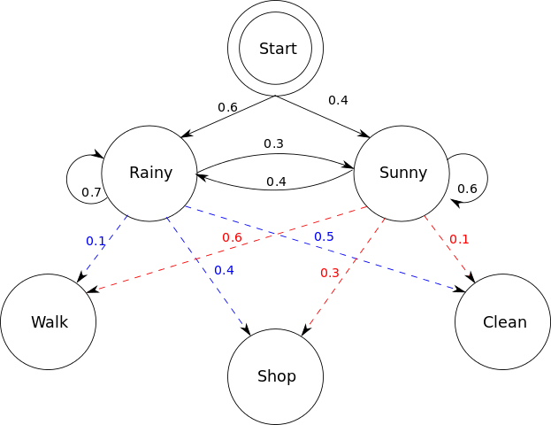

## All in One Table

| Algorithm | $t_1$ | $t_2$ | $t_3$ |
| --- | --- | --- | --- |
| Forward | $\alpha_1$(C) | $\alpha_2$(C) | $\alpha_3$(C) |
|  | $\alpha_1$(N) | $\alpha_2$(N) | $\alpha_3$(N) |
| Backward | $\beta_1$(C) | $\beta_2$(C) | $\beta_3$(C) |
|  | $\beta_1$(N) | $\beta_2$(N) | $\beta_3$(N) |
| Forward- | $\gamma_1$(C) | $\gamma_2$(C) | $\gamma_3$(C) |
| backward | $\gamma_1$(N) | $\gamma_2$(N) | $\gamma_3$(N) |

## Fitting it in R: Setup

- To begin with, we set up the baseline number of HMM.

```r
#  First, we define initial probabilit as:
#  If it is rany, what is the probability of go shopping
startProbs <- c(0.6, 0.4)

#  Then, define the transition probability, where as:
#  P(Rainy to Rainy) = 0.7, P(Rainy to Sunny) = 0.3,
#  P(Sunny to Rainy) = 0.4, P(Sunny to Sunny) = 0.6.
transProbs <- matrix(c(0.7, 0.3, 0.4, 0.6), nrow = 2)

#  Now, define emission probability with the order "Walk, Shop, Clean" as:
#  Trans probability of changing from rainy to sunny
emmissionProbs <- matrix(c(0.1, 0.6, 0.4, 0.3, 0.5, 0.1), nrow = 2)

#  Prepare basic data structure
hmm <- initHMM(c("Rainy","Sunny"), c("Walk","Shop", "Clean"),
               startProbs, transProbs, emmissionProbs)
print(hmm)
```

```
## $States
## [1] "Rainy" "Sunny"
##
## $Symbols
## [1] "Walk"  "Shop"  "Clean"
##
## $startProbs
## Rainy Sunny
##   0.6   0.4
##
## $transProbs
##        to
## from    Rainy Sunny
##   Rainy   0.7   0.4
##   Sunny   0.3   0.6
##
## $emissionProbs
##        symbols
## states  Walk Shop Clean
##   Rainy  0.1  0.4   0.5
##   Sunny  0.6  0.3   0.1
```

```r
#  Sequence of observations
observations = c("Clean", "Shop", "Walk")
```

## Fitting it in R: Forward-Backward

- Forward ($\alpha$): Pr(state at time k is X, and observe obs 1 to k)

```r
# Return the probability on the log scale, so we need to take exp.
exp(forward(hmm, observations))
```

```
##        index
## states     1      2        3
##   Rainy 0.30 0.0888 0.007512
##   Sunny 0.04 0.0432 0.036864
```

- Backward: At time k, Pr(observe obs k+1 to end | state is X)

```r
 # Again, return the probability on the log scale, so we need to take exp.
exp(backward(hmm, observations))
```

```
##        index
## states       1    2 3
##   Rainy 0.1336 0.31 1
##   Sunny 0.1074 0.39 1
```

- Posterior: P(state at time k is X | all observations)

```r
posterior(hmm, observations)
```

```
##        index
## states           1         2         3
##   Rainy 0.90319091 0.6203353 0.1692807
##   Sunny 0.09680909 0.3796647 0.8307193
```

## Viterbi

- Most likely path
- Takes into account dependency between states

```r
viterbi(hmm, observations)
```

```
## [1] "Rainy" "Rainy" "Sunny"
```

## Cheer for Experiences

CpG islands are stretches of CG-rich sequences in the genome. They are often of functional importance, as 50% of the human genes have a CpG island around 500bp upstream of the transcription start site. Of course, CpG island sequences are not only CG’s, and non-CpG island sequences could still contain some CG’s. Therefore, we could use HMMs to predict CpG islands by looking at a long stretch of DNA. Now as a HMM practice, we just have a short sequence AGGCGT.

The parameters of the HMM model are: Initial probability: 0.4 of CpG (abbreviated as C) and 0.6 of non-CpG (abbreviated as N). Transition probability: $P$(CpG to CpG) = 0.7, $P$(non-CpG to non-CpG) = 0.6. Emission probability: $P$(A, C, G, T | CpG) = (0.1, 0.4, 0.4, 0.1), $P$(A, C, G, T | non-CpG) = (0.3, 0.2, 0.2, 0.3).

## All in One Table

| Algorithm | $t_1$ | $t_2$ | $t_3$ | $t_4$ | $t_5$ | $t_6$ |
| --- | --- | --- | --- | --- | --- | --- |
| Forward | $\alpha_1$(C) | $\alpha_2$(C) | $\alpha_3$(C) | $\alpha_4$(C) | $\alpha_5$(C) | $\alpha_6$(C) |
|  | $\alpha_1$(N) | $\alpha_2$(N) | $\alpha_3$(N) | $\alpha_4$(N) | $\alpha_5$(N) | $\alpha_6$(N) |
| Backward | $\beta_1$(C) | $\beta_2$(C) | $\beta_3$(C) | $\beta_4$(C) | $\beta_5$(C) | $\beta_6$(C) |
|  | $\beta_1$(N) | $\beta_2$(N) | $\beta_3$(N) | $\beta_4$(N) | $\beta_5$(N) | $\beta_6$(N) |
| Forward- | $\gamma_1$(C) | $\gamma_2$(C) | $\gamma_3$(C) | $\gamma_4$(C) | $\gamma_5$(C) | $\gamma_6$(C) |
| backward | $\gamma_1$(N) | $\gamma_2$(N) | $\gamma_3$(N) | $\gamma_4$(N) | $\gamma_5$(N) | $\gamma_6$(N) |

## Forward-backward procedure

- Given that the observation string is AGGCGT
- Step 1: Forward Procedure

```r
alphaC1 = 0.4 * 0.1
alphaN1 = 0.6 * 0.3

alphaC2 = (alphaC1 * 0.7 + alphaN1 * 0.4) * 0.4
alphaN2 = (alphaC1 * 0.3 + alphaN1 * 0.6) * 0.2

alphaC3 = (alphaC2 * 0.7 + alphaN2 * 0.4) * 0.4
alphaN3 = (alphaC2 * 0.3 + alphaN2 * 0.6) * 0.2

alphaC4 = (alphaC3 * 0.7 + alphaN3 * 0.4) * 0.4
alphaN4 = (alphaC3 * 0.3 + alphaN3 * 0.6) * 0.2

alphaC5 = (alphaC4 * 0.7 + alphaN4 * 0.4) * 0.4
alphaN5 = (alphaC4 * 0.3 + alphaN4 * 0.6) * 0.2

alphaC6 = (alphaC5 * 0.7 + alphaN5 * 0.4) * 0.1
alphaN6 = (alphaC5 * 0.3 + alphaN5 * 0.6) * 0.3

#  Print every alpha
(alpha_set_C = c(alphaC1, alphaC2, alphaC3, alphaC4, alphaC5, alphaC6))
```

```
## [1] 0.040000000 0.040000000 0.015040000 0.005056000 0.001661440 0.000135808
```

```r
(alpha_set_N = c(alphaN1, alphaN2, alphaN3, alphaN4, alphaN5, alphaN6))
```

```
## [1] 0.180000000 0.024000000 0.005280000 0.001536000 0.000487680 0.000237312
```

- Step 2: Backward Procedure

```r
betaC6 = 1
betaN6 = 1

betaC5 = 0.7 * 0.1 * betaC6 + 0.3 * 0.3 * betaN6
betaN5 = 0.4 * 0.1 * betaC6 + 0.6 * 0.3 * betaN6

betaC4 = 0.7 * 0.4 * betaC5 + 0.3 * 0.2 * betaN5
betaN4 = 0.4 * 0.4 * betaC5 + 0.6 * 0.2 * betaN5

betaC3 = 0.7 * 0.4 * betaC4 + 0.3 * 0.2 * betaN4
betaN3 = 0.4 * 0.4 * betaC4 + 0.6 * 0.2 * betaN4

betaC2 = 0.7 * 0.4 * betaC3 + 0.3 * 0.2 * betaN3
betaN2 = 0.4 * 0.4 * betaC3 + 0.6 * 0.2 * betaN3

betaC1 = 0.7 * 0.4 * betaC2 + 0.3 * 0.2 * betaN2
betaN1 = 0.4 * 0.4 * betaC2 + 0.6 * 0.2 * betaN2

#  Print every beta
(beta_set_C = c(betaC1, betaC2, betaC3, betaC4, betaC5, betaC6))
```

```
## [1] 0.00207616 0.00635200 0.01936000 0.05800000 0.16000000 1.00000000
```

```r
(beta_set_N = c(betaN1, betaN2, betaN3, betaN4, betaN5, betaN6))
```

```
## [1] 0.00161152 0.00496000 0.01552000 0.05200000 0.22000000 1.00000000
```

- Step 3: Check the equality of the termination values

```r
(termination_alpha = alphaC6 + alphaN6)
```

```
## [1] 0.00037312
```

```r
(termination_beta = 0.4 * 0.1 * betaC1 + 0.6 * 0.3 * betaN1)
```

```
## [1] 0.00037312
```

```r
termination_alpha == termination_beta
```

```
## [1] TRUE
```

- Step 4: Calculate gamma score

```r
gammaC1 = (alphaC1 * betaC1) / (alphaC1 * betaC1 + alphaN1 * betaN1)
gammaC2 = (alphaC2 * betaC2) / (alphaC2 * betaC2 + alphaN2 * betaN2)
gammaC3 = (alphaC3 * betaC3) / (alphaC3 * betaC3 + alphaN3 * betaN3)
gammaC4 = (alphaC4 * betaC4) / (alphaC4 * betaC4 + alphaN4 * betaN4)
gammaC5 = (alphaC5 * betaC5) / (alphaC5 * betaC5 + alphaN5 * betaN5)
gammaC6 = (alphaC6 * betaC6) / (alphaC6 * betaC6 + alphaN6 * betaN6)
```

- Step 5: Print the probability of choose C as path

```r
(path_C = c(gammaC1, gammaC2, gammaC3, gammaC4, gammaC5, gammaC6))
```

```
## [1] 0.2225729 0.6809605 0.7803774 0.7859348 0.7124528 0.3639794
```

```r
#   Now we print the path
(path = ifelse( path_C < 0.5, 'N', 'C'))
```

```
## [1] "N" "C" "C" "C" "C" "N"
```

## Implementing Viterbi Algorithm

- Step 1: Initiation

```r
sigmaC1 = 0.4 * 0.1
sigmaN1 = 0.6 * 0.3
psiC1 = 0
psiN1 = 0
```

- Step 2: Recursion

```r
sigmaC2 = ( max(sigmaC1 * 0.7, sigmaN1 * 0.4) * 0.4)
sigmaN2 = ( max(sigmaN1 * 0.6, sigmaC1 * 0.3) * 0.2)

sigmaC3 = ( max(sigmaC2 * 0.7, sigmaN2 * 0.4) * 0.4)
sigmaN3 = ( max(sigmaN2 * 0.6, sigmaC2 * 0.3) * 0.2)

sigmaC4 = ( max(sigmaC3 * 0.7, sigmaN3 * 0.4) * 0.4)
sigmaN4 = ( max(sigmaN3 * 0.6, sigmaC3 * 0.3) * 0.2)

sigmaC5 = ( max(sigmaC4 * 0.7, sigmaN4 * 0.4) * 0.4)
sigmaN5 = ( max(sigmaN4 * 0.6, sigmaC4 * 0.3) * 0.2)

sigmaC6 = ( max(sigmaC5 * 0.7, sigmaN5 * 0.4) * 0.1)
sigmaN6 = ( max(sigmaN5 * 0.6, sigmaC5 * 0.3) * 0.3)

psiC2 = ifelse( (sigmaC1 * 0.7) > (sigmaN1 * 0.4), 'C', 'N' )
psiN2 = ifelse( (sigmaN1 * 0.6) > (sigmaC1 * 0.3), 'N', 'C' )

psiC3 = ifelse( (sigmaC2 * 0.7) > (sigmaN2 * 0.4), 'C', 'N' )
psiN3 = ifelse( (sigmaN2 * 0.6) > (sigmaC2 * 0.3), 'N', 'C' )

psiC4 = ifelse( (sigmaC3 * 0.7) > (sigmaN3 * 0.4), 'C', 'N' )
psiN4 = ifelse( (sigmaN3 * 0.6) > (sigmaC3 * 0.3), 'N', 'C' )

psiC5 = ifelse( (sigmaC4 * 0.7) > (sigmaN4 * 0.4), 'C', 'N' )
psiN5 = ifelse( (sigmaN4 * 0.6) > (sigmaC4 * 0.3), 'N', 'C' )

psiC6 = ifelse( (sigmaC5 * 0.7) > (sigmaN5 * 0.4), 'C', 'N' )
psiN6 = ifelse( (sigmaN5 * 0.6) > (sigmaC5 * 0.3), 'N', 'C' )
```

- Step 3: Termination

```r
q_star6 = ifelse( sigmaC6 > sigmaN6, 'C', 'N')
```

- Step 4: Path backtracking

```r
q_star5 = ifelse( q_star6 == 'C', psiC6, psiN6)
q_star4 = ifelse( q_star5 == 'C', psiC5, psiN6)
q_star3 = ifelse( q_star4 == 'C', psiC4, psiN4)
q_star2 = ifelse( q_star3 == 'C', psiC3, psiN3)
q_star1 = ifelse( q_star2 == 'C', psiC2, psiN2)

##  Now we print the path
(path_viterbi = c(q_star1, q_star2, q_star3, q_star4, q_star5, q_star6))
```

```
## [1] "N" "C" "C" "C" "C" "N"
```

## Part II: The Cancer Genome Atlas (TCGA)

- Overview of TCGA database
- Access data from TCGA
- Tumor subtype analysis
- Expression Data: Clustering and PCA

## TCGA Website

- TCGA’s website contains raw data that you can download
- Should be fairly straightforward, involves searching on the provided website.

## Broad Firehose

- Contains processed data that you can download and analyze
- Access using firebrowse
- R API: FirebrowseR
- Code adapted from FirebrowseR vignette: https://github.com/mariodeng/FirebrowseR
- Let’s download all breast cancer patients’ clinical data.

```r
# Install required packages
source("https://bioconductor.org/biocLite.R")
biocLite("limma")
biocLite("bladderbatch")
biocLite("sva")
install.packages("devtools")
library(devtools)
devtools::install_github("mariodeng/FirebrowseR")
```

```r
# Library riquired packages
library(FirebrowseR)
library(bladderbatch)
library(limma)
library(sva)
library(dplyr)
library(glmnet)
library(ggplot2)
```

```r
# download all available cohorts
cohorts <- Metadata.Cohorts(format = "csv")
# show what cohorts are available
cohorts
```

```
##      cohort
## 1       ACC
## 2      BLCA
## 3      BRCA
## 4      CESC
## 5      CHOL
## 6      COAD
## 7  COADREAD
## 8      DLBC
## 9      ESCA
## 10     FPPP
## 11      GBM
## 12   GBMLGG
## 13     HNSC
## 14     KICH
```

[output cut: 63 more lines]

```r
# have to do this because we can only receive 150 patients at a time
all.Received <- FALSE
page.Counter <- 1
page.size <- 150
brca_pats <- list()
while(all.Received == FALSE) {
    brca_pats[[page.Counter]] <- Samples.Clinical(format = "csv",
            cohort = "BRCA", page_size = page.size, page = page.Counter)
    if(page.Counter > 1) {
        colnames(brca_pats[[page.Counter]]) <-
            colnames(brca_pats[[page.Counter-1]])
    }

    if(nrow(brca_pats[[page.Counter]]) < page.size) {
        all.Received = TRUE
    } else {
        page.Counter = page.Counter + 1
    }
}

brca_pats <- do.call(rbind, brca_pats)
dim(brca_pats)
```

```
## [1] 1097  111
```

Now, can you find out how many are alive? How about the mean and median age at initial diagnosis? Can you plot a histogram of the age at initial diagnosis?

```r
table(brca_pats$vital_status)
```

```
##
## alive  dead
##   945   152
```

```r
mean(brca_pats$age_at_initial_pathologic_diagnosis)
```

```
## [1] 58.46308
```

```r
median(brca_pats$age_at_initial_pathologic_diagnosis)
```

```
## [1] 58
```

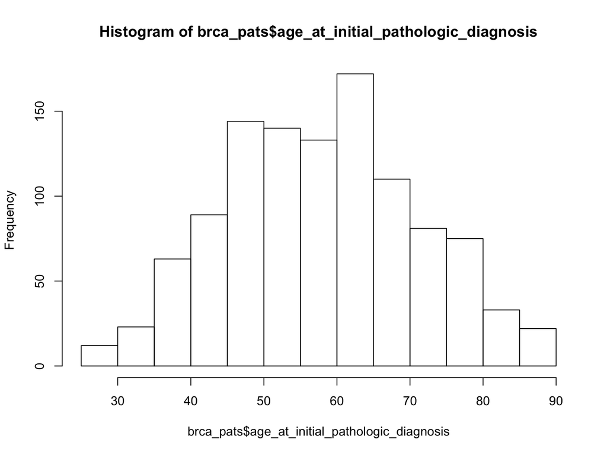

```r
hist(brca_pats$age_at_initial_pathologic_diagnosis)
```

## Tumor Subtype Analysis

- Using LIMMA to find differentially expressed genes. Please review Lab 2.
- You can assume that we have already performed normalization (RMA) and batch effect removal (ComBat), so you can jump right in to using LIMMA.

## Expression Data: Clustering and PCA

Task: using the bladder batch data, can you perform kmeans clustering (try $k = 2$ for now) on differentially expressed genes (FDR $< 0.05$ and log2-fold-change $> 2$), and then plot the result on a PCA plot, with the color of each point denoting its cluster and the shape denoting its cancer status?

```r
set.seed(282215115)
# I am running ComBat because this data has batch effect, but you don't
# need this for your HW
data(bladderdata)
pheno <- pData(bladderEset)
pheno$hasCancer <- as.numeric(pheno$cancer == "Cancer")
edata <- exprs(bladderEset)
model <- model.matrix(~hasCancer, data = pheno)
combat_edata <- ComBat(dat = edata, batch = pheno$batch, mod = model)
```

```
## Found5batches
```

```
## Adjusting for1covariate(s) or covariate level(s)
```

```
## Standardizing Data across genes
```

```
## Fitting L/S model and finding priors
```

```
## Finding parametric adjustments
```

```
## Adjusting the Data
```

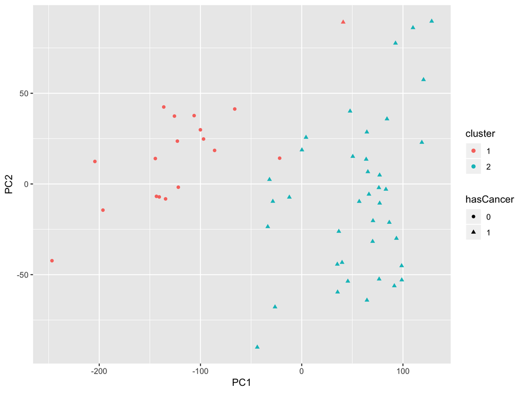

```r
# run LIMMA to get the top genes (use data after running ComBat)
fit <- lmFit(combat_edata, model)
fit <- eBayes(fit)
topgenes <- topTable(fit, coef = "hasCancer", p.value = 0.05, lfc = 2,
                     number = Inf)

# run kmeans clustering on top genes
kmeans_res <- kmeans(t(combat_edata[rownames(topgenes),]),
                     2, nstart = 10, iter.max = 100)

# In the homework, we are supposed to use k.means as 3
# PCA is just plotting, but kmeans is actually doing the cluster tasks.

# run PCA
pca_raw <- prcomp(t(combat_edata), center = TRUE, scale. = TRUE)

# assemble the data
edata_pc_df <- as.data.frame(pca_raw$x)
edata_pc_df$cluster <- as.factor(kmeans_res$cluster)
edata_pc_df$hasCancer <- as.factor(pheno$hasCancer)

# draw the plot
ggplot(edata_pc_df, aes(x = PC1, y = PC2, color = cluster, shape =
                        hasCancer)) + geom_point()
```

## Acknowledgement

- Dr. X. Shirley Liu
- Dr. Changxing Wan
- Andy Shi

## Good Luck!

- Office hour until 7:00 pm for Tuesday
- Office hour until 8:00 pm for Thursday
- Additional office hour on each Friday 11:30 am - 12:30 pm @ HSPH Building 2 Room 428